# PS3 Jeremy Tan

Loading CSV

```r
data_1 = read.csv("PS3.csv")
data_1 = data_1[-1] # remove ID column
data_1
```

| y | x01 | x02 | x03 | x04 | x05 | x06 | x07 | x08 | x09 | x10 | x11 | x12 |
| --- | --- | --- | --- | --- | --- | --- | --- | --- | --- | --- | --- | --- |
| 25.3209 | 1.61 | 1.15 | 0.53 | 0.89 | 1.93 | 2.66 | 56 | 47 | 53 | 3.51 | 10.490 | 4.940 |
| 11.1852 | 1.61 | 0.76 | 0.53 | 0.89 | 0.98 | 2.20 | 56 | 3 | 76 | 3.51 | 0.535 | 22.590 |
| 16.2945 | 1.61 | 1.02 | 0.53 | 0.89 | 0.93 | 2.66 | 56 | 11 | 53 | 3.51 | 0.968 | 4.940 |
| 14.8078 | 1.61 | 1.02 | 0.53 | 0.89 | 0.93 | 2.20 | 56 | 11 | 76 | 3.51 | 0.968 | 22.590 |
| 9.0212 | 1.34 | 0.76 | 0.53 | 1.00 | 0.98 | 2.20 | 20 | 3 | 76 | 1.55 | 0.535 | 22.590 |
| 9.0514 | 1.34 | 0.76 | 0.53 | 1.00 | 0.98 | 1.90 | 20 | 3 | 75 | 1.55 | 0.535 | 21.020 |
| 9.2891 | 1.44 | 0.76 | 0.53 | 0.95 | 0.98 | 1.90 | 38 | 3 | 75 | 2.63 | 0.535 | 21.020 |
| 11.7087 | 1.44 | 1.02 | 0.53 | 0.95 | 0.93 | 2.20 | 38 | 11 | 76 | 2.63 | 0.968 | 22.590 |
| 32.4948 | 1.61 | 1.03 | 0.64 | 0.89 | 1.90 | 1.50 | 56 | 83 | 73 | 3.51 | 9.780 | 16.650 |
| 45.3982 | 1.61 | 1.01 | 0.78 | 0.89 | 1.12 | 1.50 | 56 | 58 | 91 | 3.51 | 6.689 | 15.370 |

[output cut: 137 more lines]

1. Fit a linear model to the given data

Full Model All Variables

```r
model1 = summary(lm(y ~., data = data_1))
model1
```

```
Call:
lm(formula = y ~ ., data = data_1)

Residuals:
     Min       1Q   Median       3Q      Max
-14.4850  -2.7802  -0.2502   2.9391  12.6975

Coefficients:
              Estimate Std. Error t value Pr(>|t|)
(Intercept) -139.58970   72.51657  -1.925  0.05636 .
x01           91.57240   48.09504   1.904  0.05906 .
x02           17.34218    3.77987   4.588 1.02e-05 ***
x03            9.52072    6.90665   1.378  0.17035
x04           24.49670   17.02610   1.439  0.15255
x05           -5.41615    2.42357  -2.235  0.02709 *
x06           -4.27759    2.04530  -2.091  0.03838 *
x07           -0.51718    0.36820  -1.405  0.16244
x08            0.15565    0.04409   3.530  0.00057 ***
x09            0.27336    0.03823   7.151 5.04e-11 ***
x10           -0.02014    0.57582  -0.035  0.97215
x11           -0.08652    0.34406  -0.251  0.80184
x12           -0.61904    0.11823  -5.236 6.20e-07 ***
---
Signif. codes:  0 ‘***’ 0.001 ‘**’ 0.01 ‘*’ 0.05 ‘.’ 0.1 ‘ ’ 1

Residual standard error: 4.824 on 134 degrees of freedom
Multiple R-squared:  0.8163,    Adjusted R-squared:  0.7999
F-statistic: 49.63 on 12 and 134 DF,  p-value: < 2.2e-16
```

```r
model_1 = lm(y ~., data = data_1)
```

The regression coefficients

```r
model1$coefficients
```

```
                 Estimate  Std. Error     t value     Pr(>|t|)
(Intercept) -139.58969648 72.51657066 -1.92493516 5.635654e-02
x01           91.57240283 48.09503584  1.90398866 5.905559e-02
x02           17.34218119  3.77986594  4.58804134 1.016677e-05
x03            9.52071607  6.90664708  1.37848597 1.703504e-01
x04           24.49670330 17.02610039  1.43877357 1.525464e-01
x05           -5.41614994  2.42357139 -2.23478044 2.708761e-02
x06           -4.27758804  2.04529869 -2.09142462 3.837785e-02
x07           -0.51718427  0.36819569 -1.40464510 1.624406e-01
x08            0.15564832  0.04408910  3.53031293 5.695137e-04
x09            0.27335642  0.03822564  7.15112676 5.042774e-11
x10           -0.02014261  0.57581516 -0.03498104 9.721469e-01
x11           -0.08651679  0.34405695 -0.25146066 8.018432e-01
x12           -0.61904349  0.11823439 -5.23573122 6.198813e-07
```

2. Check the fit of the model, and identify which coefficients are significant.

Given alpha (level of significance) = 0.05, x02,x05,x06,x08,x09,x12 are the significant coefficients since their p-value is less than alpha.

The fit of the model is measured by the Rsquared value, the coefficient of determination. This is the proportion of the total sum of squares due to regression. Since later on we will be using reduced models with fewer variables, we are going to use adjusted R squared which takes into account the number of independent variables in the model.

```r
model1$adj.r.squared
```

```
[1] 0.7998815
```

This means that our model can explain 80% of the total variation of y around its mean. Since our adjusted R^2 is between 0.75 to 1.00, our model is a good fit for the data.

3. Perform model diagnostics by identifying which variables should be included, analyzing the resulting residuals, and testing for multicollinearity.

Variable Selection

```r
library(leaps)
nvar = ncol(data_1) - 1 #id col, and y-int are not included
varsel = regsubsets(y~., data = data_1, nvmax= 13)
varsel.res = summary(varsel)
varsel.res
```

```
Subset selection object
Call: regsubsets.formula(y ~ ., data = data_1, nvmax = 13)
12 Variables  (and intercept)
    Forced in Forced out
x01     FALSE      FALSE
x02     FALSE      FALSE
x03     FALSE      FALSE
x04     FALSE      FALSE
x05     FALSE      FALSE
x06     FALSE      FALSE
x07     FALSE      FALSE
x08     FALSE      FALSE
x09     FALSE      FALSE
x10     FALSE      FALSE
x11     FALSE      FALSE
x12     FALSE      FALSE
1 subsets of each size up to 12
Selection Algorithm: exhaustive
          x01 x02 x03 x04 x05 x06 x07 x08 x09 x10 x11 x12
1  ( 1 )  " " " " " " " " " " " " " " "*" " " " " " " " "
2  ( 1 )  " " "*" "*" " " " " " " " " " " " " " " " " " "
3  ( 1 )  " " "*" "*" " " " " " " " " "*" " " " " " " " "
4  ( 1 )  " " "*" " " " " " " " " " " "*" "*" " " " " "*"
5  ( 1 )  "*" " " " " " " "*" " " " " "*" "*" " " " " "*"
6  ( 1 )  "*" "*" " " " " "*" " " " " "*" "*" " " " " "*"
7  ( 1 )  "*" "*" " " " " "*" "*" " " "*" "*" " " " " "*"
8  ( 1 )  "*" "*" "*" " " "*" "*" " " "*" "*" " " " " "*"
9  ( 1 )  "*" "*" " " "*" "*" "*" "*" "*" "*" " " " " "*"
10  ( 1 ) "*" "*" "*" "*" "*" "*" "*" "*" "*" " " " " "*"
11  ( 1 ) "*" "*" "*" "*" "*" "*" "*" "*" "*" " " "*" "*"
12  ( 1 ) "*" "*" "*" "*" "*" "*" "*" "*" "*" "*" "*" "*"
```

```r
names(varsel.res)
```

```
[1] "which"  "rsq"    "rss"    "adjr2"  "cp"     "bic"    "outmat" "obj"
```

We will only be considering 1 metric, BIC or the Bayesian Information Criterion. The model with the lowest BIC is usually preferred, as it strikes a balance between goodness of fit and model complexity.

```r
varsel.metric = cbind(1:nvar, varsel.res$bic, varsel.res$cp)
colnames(varsel.metric) = c("No. of Variables", "BIC", "cp")
varsel.metric
```

```
      No. of Variables        BIC         cp
 [1,]                1  -66.37373 290.995016
 [2,]                2 -128.75107 133.444458
 [3,]                3 -150.44266  89.889309
 [4,]                4 -173.05911  52.698626
 [5,]                5 -188.38451  30.212687
 [6,]                6 -198.19422  16.388817
 [7,]                7 -204.55991   7.282669
 [8,]                8 -201.83125   7.171306
 [9,]                9 -197.06974   8.959406
[10,]               10 -194.14157   9.065352
[11,]               11 -189.22147  11.001224
[12,]               12 -184.23238  13.000000
```

We plot the BIC against the number of variables in the model

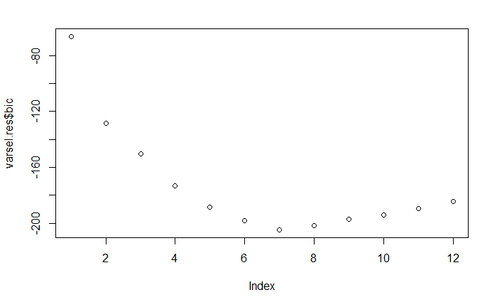

```r
plot(varsel.res$bic) #BIC
```

We find the variables which will result in the lowest BIC value.

```r
varsel.res$which[which.min(varsel.res$bic),] #BIC
```

```
(Intercept)         x01         x02         x03         x04         x05         x06         x07         x08
       TRUE        TRUE        TRUE       FALSE       FALSE        TRUE        TRUE       FALSE        TRUE
        x09         x10         x11         x12
       TRUE       FALSE       FALSE        TRUE
```

The variables which will result in the lowest BIC are x01,x02,x05,x06,x08,x09,x12.

We will select these 7 variables: x01,x02,x05,x06,x08,x09,x12 for our reduced model.

```r
reduced_model_1 = lm(y ~ x01 + x02 + x05 + x06 + x08 + x09 + x12, data = data_1)
reduced_model1 = summary(reduced_model_1)
reduced_model1
```

```
Call:
lm(formula = y ~ x01 + x02 + x05 + x06 + x08 + x09 + x12, data = data_1)

Residuals:
     Min       1Q   Median       3Q      Max
-12.5840  -2.7843  -0.5895   2.7654  14.3002

Coefficients:
             Estimate Std. Error t value Pr(>|t|)
(Intercept) -28.47514    9.96275  -2.858  0.00492 **
x01          23.60338    5.72485   4.123 6.40e-05 ***
x02          17.47304    3.74160   4.670 7.03e-06 ***
x05          -6.35633    1.45473  -4.369 2.42e-05 ***
x06          -5.72048    1.71209  -3.341  0.00107 **
x08           0.15021    0.02577   5.828 3.73e-08 ***
x09           0.29431    0.03124   9.420  < 2e-16 ***
x12          -0.66556    0.10573  -6.295 3.76e-09 ***
---
Signif. codes:  0 ‘***’ 0.001 ‘**’ 0.01 ‘*’ 0.05 ‘.’ 0.1 ‘ ’ 1

Residual standard error: 4.811 on 139 degrees of freedom
Multiple R-squared:  0.8105,    Adjusted R-squared:  0.8009
F-statistic: 84.91 on 7 and 139 DF,  p-value: < 2.2e-16
```

Comparison of Fit between the full and reduced models

```r
model1$adj.r.squared
```

```
[1] 0.7998815
```

```r
reduced_model1$adj.r.squared
```

```
[1] 0.8009142
```

```r
anova(model_1, reduced_model_1)
```

```
Analysis of Variance Table

Model 1: y ~ x01 + x02 + x03 + x04 + x05 + x06 + x07 + x08 + x09 + x10 +
    x11 + x12
Model 2: y ~ x01 + x02 + x05 + x06 + x08 + x09 + x12
  Res.Df    RSS Df Sum of Sq      F Pr(>F)
1    134 3118.3
2    139 3217.9 -5    -99.66 0.8565 0.5123
```

The reduced model is slightly better fitting compared to the full model; however since the p value in the anova test is 0.5123, which is greater then 0.05, the difference is not significant. We can conclude that the predictive power of both models is roughly the same.

Residual Analysis

We have to check if the residuals are uncorrelated and if they are normalized as this is one of the assumptions of a multiple linear regression model.

Normal QQ Plot

First, we check the residuals of model1 or the complete model.

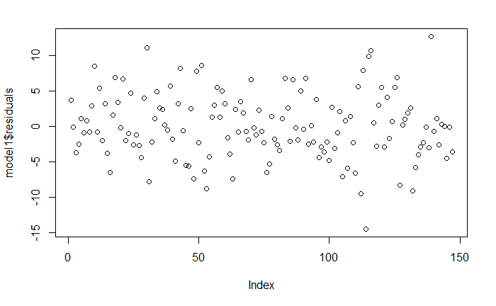

```r
library(nortest)
plot(model1$residuals)
```

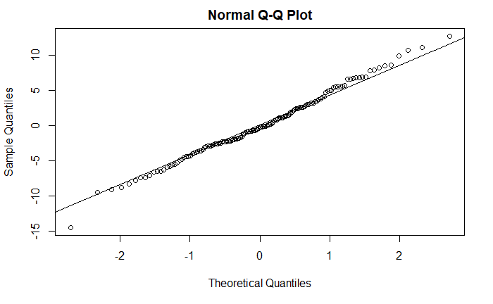

```r
qqnorm(model1$residuals)
qqline(model1$residuals)
```

Residuals of the reduced model

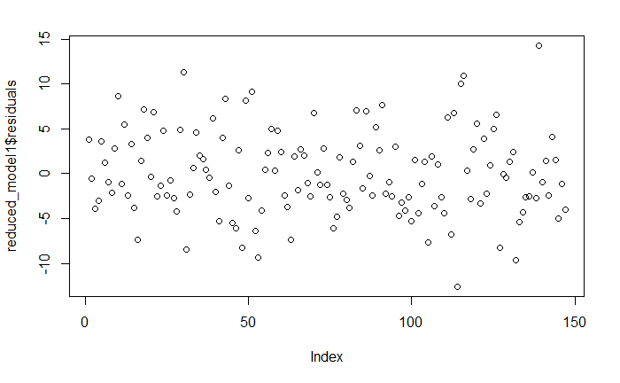

```r
library(nortest)
plot(reduced_model1$residuals)
```

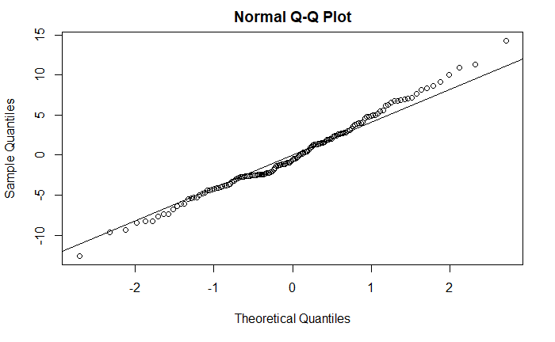

```r
qqnorm(reduced_model1$residuals)
qqline(reduced_model1$residuals)
```

For both the complete and reduced models, the residuals don’t form a distinct line and are randomly distributed, meaning that the residuals are not correlated.

The quantiles of the residuals almost perfectly fall on the normal QQ line. This means that the residuals for both the full and reduced models follow a normal distribution.

```r
cat("Full Model")
```

```
Full Model
```

```r
ad.test(model1$residuals) #Anderson-Darling
```

```
    Anderson-Darling normality test

data:  model1$residuals
A = 0.36558, p-value = 0.4312
```

```r
shapiro.test(model1$residuals) #Shapiro-Wilk
```

```
    Shapiro-Wilk normality test

data:  model1$residuals
W = 0.99368, p-value = 0.7691
```

```r
cat("Reduced Model")
```

```
Reduced Model
```

```r
ad.test(reduced_model1$residuals) #Anderson-Darling
```

```
    Anderson-Darling normality test

data:  reduced_model1$residuals
A = 0.60152, p-value = 0.1163
```

```r
shapiro.test(reduced_model1$residuals) #Shapiro-Wilk
```

```
    Shapiro-Wilk normality test

data:  reduced_model1$residuals
W = 0.99078, p-value = 0.4518
```

This assumption of normality is verified by the AD and SW tests. The null hypothesis of both the AD and SW tests is that the residuals follow a normal distribution. In both tests for the full and reduced models, the p value > alpha = 0.05 so we fail to reject the null hypothesis that the residuals follow a normal distribution.

Testing Multicollinearity

We retain the variable if its variance inflation factor is less than 5. The VIF (variance inflation factor) measures how reliably a variable is predicted by the other variables.

First, we check the full model.

```r
library(car)
vif(model_1)
```

```
      x01       x02       x03       x04       x05       x06       x07       x08       x09       x10       x11
92.221080  1.987640  2.833045 40.266695  4.203389  2.317247 90.295026  5.697418  3.131424  3.230250  7.286726
      x12
 2.438326
```

The variables: x01, x04, x07, x08, and x11 all have significant multicollinearity, which means that these variables have a significant correlation with the other variables.

In particular, x01, x04, x07 are highly correlated with a VIF greater than 10. This means that we can remove two out of the three variables since these variables essentially have the same relationship with the dependent variable. In our case, we only keep x01 in the reduced model.

VIF of the reduced model

```r
vif(reduced_model_1)
```

```
     x01      x02      x05      x06      x08      x09      x12
1.313426 1.957701 1.522306 1.632148 1.956929 2.102893 1.959864
```

In the reduced model, all the variables’ VIF are below 5 so none of the variables are significantly correlated or can be reliably predicted by the other variables. There is little multicollinearity between the variables.

2. In some cases, data transformations are necessary to improve the fit of the linear model. Consider the transformation z = ln y for the data given in PS3.csv.

Transforming the data

```r
library(tidyverse)
data_2 = data_1
data_2 = transform(data_2, y = log(y))
data_2 = rename(data_2, z = y)
data_2
```

| z | x01 | x02 | x03 | x04 | x05 | x06 | x07 | x08 | x09 | x10 | x11 | x12 |
| --- | --- | --- | --- | --- | --- | --- | --- | --- | --- | --- | --- | --- |
| 3.231630 | 1.61 | 1.15 | 0.53 | 0.89 | 1.93 | 2.66 | 56 | 47 | 53 | 3.51 | 10.490 | 4.940 |
| 2.414591 | 1.61 | 0.76 | 0.53 | 0.89 | 0.98 | 2.20 | 56 | 3 | 76 | 3.51 | 0.535 | 22.590 |
| 2.790828 | 1.61 | 1.02 | 0.53 | 0.89 | 0.93 | 2.66 | 56 | 11 | 53 | 3.51 | 0.968 | 4.940 |
| 2.695154 | 1.61 | 1.02 | 0.53 | 0.89 | 0.93 | 2.20 | 56 | 11 | 76 | 3.51 | 0.968 | 22.590 |
| 2.199577 | 1.34 | 0.76 | 0.53 | 1.00 | 0.98 | 2.20 | 20 | 3 | 76 | 1.55 | 0.535 | 22.590 |
| 2.202919 | 1.34 | 0.76 | 0.53 | 1.00 | 0.98 | 1.90 | 20 | 3 | 75 | 1.55 | 0.535 | 21.020 |
| 2.228842 | 1.44 | 0.76 | 0.53 | 0.95 | 0.98 | 1.90 | 38 | 3 | 75 | 2.63 | 0.535 | 21.020 |
| 2.460332 | 1.44 | 1.02 | 0.53 | 0.95 | 0.93 | 2.20 | 38 | 11 | 76 | 2.63 | 0.968 | 22.590 |
| 3.481080 | 1.61 | 1.03 | 0.64 | 0.89 | 1.90 | 1.50 | 56 | 83 | 73 | 3.51 | 9.780 | 16.650 |
| 3.815472 | 1.61 | 1.01 | 0.78 | 0.89 | 1.12 | 1.50 | 56 | 58 | 91 | 3.51 | 6.689 | 15.370 |

[output cut: 137 more lines]

1. Fit a linear model to the given data.

```r
model2 = summary(lm(z ~., data = data_2))
model2
```

```
Call:
lm(formula = z ~ ., data = data_2)

Residuals:
    Min      1Q  Median      3Q     Max
-0.5837 -0.1117  0.0000  0.1110  0.5363

Coefficients:
             Estimate Std. Error t value Pr(>|t|)
(Intercept) -4.378075   2.681674  -1.633  0.10490
x01          4.126398   1.778562   2.320  0.02185 *
x02          0.859452   0.139780   6.149 8.40e-09 ***
x03          0.483531   0.255409   1.893  0.06049 .
x04          0.860407   0.629628   1.367  0.17406
x05         -0.246589   0.089624  -2.751  0.00676 **
x06         -0.189448   0.075635  -2.505  0.01345 *
x07         -0.019324   0.013616  -1.419  0.15817
x08          0.007767   0.001630   4.764 4.88e-06 ***
x09          0.011124   0.001414   7.869 1.06e-12 ***
x10          0.001597   0.021294   0.075  0.94033
x11         -0.006227   0.012723  -0.489  0.62534
x12         -0.026724   0.004372  -6.112 1.00e-08 ***
---
Signif. codes:  0 ‘***’ 0.001 ‘**’ 0.01 ‘*’ 0.05 ‘.’ 0.1 ‘ ’ 1

Residual standard error: 0.1784 on 134 degrees of freedom
Multiple R-squared:  0.886, Adjusted R-squared:  0.8758
F-statistic: 86.77 on 12 and 134 DF,  p-value: < 2.2e-16
```

```r
model_2 = lm(z~., data = data_2 )
```

2. Check the fit of the model, and identify which coefficients are significant.

The fit of the model is given by the adjusted R^2 value, coefficient of determination. This metric penalizes excess independent variables which don’t improve the fit of the model.

```r
model2$adj.r.squared
```

[output not shown]

The adjusted R squared value of our transformed model is 0.8758, which means it is a very good fit for the data.

The significant coefficients are those coefficients whose p value is less than alpha, 0.05.

```r
model2$coefficients
```

[output not shown]

The significant variables in our model are x01,x02,x05,x06,x08,x09,x12.

Let’s create a reduced model where we only use the significant variables.

```r
reduced_model2 = summary(lm(z ~x01 + x02 + x05 + x06 + x08 + x09 + x12, data = data_2))
reduced_model2
reduced_model_2 = lm(z ~x01 + x02 + x05 + x06 + x08 + x09 + x12, data = data_2)
```

[output not shown]

```r
model2$adj.r.squared
reduced_model2$adj.r.squared
anova(model_2, reduced_model_2)
```

[output not shown]

The adjusted R squared of the reduced model is 0.8749, which is slightly lower than the adj. R squared of the full model. However, since the p-value in the anova test is 0.3111, we can say the difference is insignificant, and both models have around the same predictive power.

3. Compare this model with the previous linear model. Which of the two models is a better fit for the given data? Justify your answer.

First, we compare the two full models.

We compared the adjusted R squared value of both models.

```r
model1$adj.r.squared
model2$adj.r.squared
```

[output not shown]

The higher adjusted r squared of the second model means that the model with the transformed dependent variable z is better fitting compared to the first model. It can explain more of the variation of the transformed dependent variable.

Next, we check the BIC metric of both models.

```r
# For Model 1
varsel_1 = regsubsets(y~., data=data_1, nvmax=nvar)
varsel.res_1 = summary(varsel_1)
varsel.metric_1 = cbind(1:nvar, varsel.res_1$bic)
colnames(varsel.metric_1) = c("No. of Variables", "BIC")
varsel.metric_1
```

[output not shown]

```r
# For Model 2
varsel_2 = regsubsets(z~., data=data_2, nvmax=nvar)
varsel.res_2 = summary(varsel_2)
varsel.metric_2 = cbind(1:nvar, varsel.res_2$bic)
colnames(varsel.metric_2) = c("No. of Variables", "BIC")
varsel.metric_2
```

[output not shown]

In terms of BIC, looking at the full model (no. of variables = 12), the second model has a significantly lower BIC, -254.314 compared to the first model, -184.232.

We can also compare the residual standard error of both models, where a lower residual means that the model is better fitting.

```r
model1$sigma
model2$sigma
```

[output not shown]

The residual standard error of model2 is significantly less than that of model1.

Lastly, we have to check if the residuals of both models are normal and uncorrelated. We use the QQ plot, Shapiro Wilk, and Anderson Darling tests.

```r
ad.test(model1$residuals) #Anderson-Darling
shapiro.test(model1$residuals) #Shapiro-Wilk
ad.test(model2$residuals) #Anderson-Darling
shapiro.test(model2$residuals) #Shapiro-Wilk
```

[output not shown]

The p-values of the 1st and 2nd models under the AD and SW normality tests are greater than 0.05. This means that we can assume that the residuals from both models are normally distributed.

The next question is which residuals are more normal?

For Model 1

```r
plot(model1$residuals)
qqnorm(model1$residuals)
qqline(model1$residuals)
```

[output not shown]

For Model 2 (transformed y)

```r
plot(model2$residuals)
qqnorm(model2$residuals)
qqline(model2$residuals)
```

[output not shown]

Final Comparison between normal linear model and transformed linear model

```r
# Model 1
cat("Comparison of the two full models\n")
```

```
Comparison of the two full models
```

```r
cat("Model 1:", "\n", "Adjusted R squared =", model1$adj.r.squared, "\n", "BIC value = ", BIC(model_1), "\n", "Residual Standard Error = ", model1$sigma, "\n" )
```

```
Model 1:
 Adjusted R squared = 0.7998815
 BIC value =  936.0594
 Residual Standard Error =  4.823953
```

```r
# Model 2
cat("Model 2:", "\n", "Adjusted R squared =", model2$adj.r.squared, "\n", "BIC value = ", BIC(model_2), "\n", "Residual Standard Error = ", model2$sigma )
```

```
Model 2:
 Adjusted R squared = 0.8757667
 BIC value =  -33.36845
 Residual Standard Error =  0.1783906
```

Thus, we can conclude that for the full models with all 12 variables, the second model with the transformed dependent variable z is better fitting compared to the first model.